# Differential expression analysis for 2026-01 release MSK_ISL1_OE, ISL1_OE vs control

Si Liu, Wei Sun

2026-09-06

Differential expression using the bulk RNAseq MSK_ISL1_OE from the Jan. 2026 release, for ISL1_OE vs control.

This dataset spans

- H1,
- day18, (final_timepoint: “yes”),
- four different colonal cell lines,
- pancreatic islet,
- OE of BFP only as control, and OE of ISL1 as case.

The test of DE analysis planned:

- for each colonal cell line, ISL1 OE vs control

The dispersion parameter estimate for one gene GCG (ENSG00000115263) is patched

- this is the only gene with -log10(pvalue from limma-voom / pvalue from DESeq2) > 3
- for this highly expressed genes, the dispersion estimate is patched to DESeq2’s un-reverted niter=2 value, since the default niter=1 fit’s noIncrease guard discarded the correct low dispersion and kept an inflated design-blind seed, inflating the standard error and masking a genuine effect.

## R libraries.

```r
library(ggplot2)
library(ggrepel)
library(ggpubr)
library(stringr)
library(MASS)
library(RColorBrewer)
library(DESeq2)

library(viridis)
library(ggpointdensity)
library(dplyr)
library(data.table)
library(ComplexHeatmap)
library(UpSetR)
library(readxl)
theme_set(theme_classic())

path = "../../MorPhiC/data/MorPhiC_internal_releases/MorPhiC_Release_January_2026/MSK_bulkRNAseq_ISL1_OE"
dat_path = file.path(path, "processed/Tables")

meta_save_path = "./data/Jan_2026"
meta_file = file.path(meta_save_path, "MSK_bulkRNAseq_ISL1_OE_meta_data.tsv")

qc_path = "./qc_figures"
# create the figure path if it does not exist
dir.create(qc_path, showWarnings = FALSE, recursive = TRUE)
```

## Load processed meta data table

```r
meta = fread(meta_file, sep="\t", data.table = FALSE)
dim(meta)
```

```
## [1] 21  8
```

## Read in gene count data and filter genes

There are redundancy in the count data file.

```
The 2nd and 3rd columns are the same and only one of them should be kept.
Only keep the columns that show up in the sequence table
```

```r
cts_lanes = fread(file.path(dat_path, "genesCounts.csv"), data.table = FALSE)
dim(cts_lanes)
```

```
## [1] 38592    98
```

```r
cts_lanes[1:2, c(1:2, (ncol(cts_lanes)-1):ncol(cts_lanes))]
```

```
##              Name PAX6-ISL1-2_IGO_17695_23_S117_L003
## 1 ENSG00000268674                                  0
## 2 ENSG00000271254                                149
##   ISL1-ISL1-1_IGO_17695_17_S124_L002 PAX6-BFP-1_IGO_17695_14_S8_L006
## 1                                  0                               0
## 2                                214                             282
```

```r
names(cts_lanes)[1:6]
```

```
## [1] "Name"                               "PAX6-ISL1-2_IGO_17695_23_S117_L003"
## [3] "PAX6-ISL1-2_IGO_17695_23_S117_L003" "PAX6-ISL1-1_IGO_17695_15_S7_L005"
## [5] "ISL1-BFP-2_IGO_17695_24_S116_L002"  "PDX1-BFP-1_IGO_17695_12_S125_L004"
```

```r
length(unique(colnames(cts_lanes)[2:ncol(cts_lanes)]))
```

```
## [1] 96
```

```r
# remove the third column from the cts_lanes object since it is a duplicate of the second column
cts_lanes = cts_lanes[,-3]
names(cts_lanes)[1:6]
```

```
## [1] "Name"                               "PAX6-ISL1-2_IGO_17695_23_S117_L003"
## [3] "PAX6-ISL1-1_IGO_17695_15_S7_L005"   "ISL1-BFP-2_IGO_17695_24_S116_L002"
## [5] "PDX1-BFP-1_IGO_17695_12_S125_L004"  "WT-ISL1-1_IGO_17695_11_S126_L004"
```

```r
# only keep the columns that show up in the sequence table
# summarized as the info in the sample_id column of meta data table
names_short = gsub("_L00[1-8]$", "", names(cts_lanes))
cols2kp = which(names_short %in% meta$sample_id)
length(cols2kp)
```

```
## [1] 84
```

```r
cts_lanes = cts_lanes[, c(1, cols2kp)]
dim(cts_lanes)
```

```
## [1] 38592    85
```

```r
names_short_filterd = gsub("_L00[1-8]$", "", names(cts_lanes))

stopifnot(setequal(names_short_filterd[-1], meta$sample_id))

# Separate the gene ID column from the count columns
gene_column <- cts_lanes$Name
counts   <- as.matrix(cts_lanes[, -1])   # drop the "Name" column

# Derive sample ID from each column name by stripping "_L00X" at the end
sample_id <- sub("_L00[1-8]$", "", colnames(counts))

# Sum lane columns belonging to the same sample.
collapsed <- t(rowsum(t(counts), group = sample_id))

# shorten column names further to just "ISL1-BFP-1" etc.
colnames(collapsed) <- sub("_IGO.*", "", colnames(collapsed))

# Put the gene IDs back as a column
cts <- data.frame(Name = gene_column, collapsed, check.names = FALSE)

head(cts)
```

```
##              Name ISL1-BFP-1 ISL1-BFP-2 ISL1-BFP-3 ISL1-ISL1-1 ISL1-ISL1-2
## 1 ENSG00000268674          0          0          0           0           0
## 2 ENSG00000271254        797        804       1265         959         805
## 3 ENSG00000275063          0          0          0           0           0
## 4 ENSG00000277856          0          0          0           0           0
## 5 ENSG00000276345         11          2          2           8           3
## 6 ENSG00000278633          0          0          0           1           0
##   ISL1-ISL1-3 PAX6-BFP-1 PAX6-BFP-2 PAX6-BFP-3 PAX6-ISL1-1 PAX6-ISL1-2
## 1           0          1          0          0           0           0
## 2        1133       1099        931       1223         495         702
## 3           0          0          0          0           0           0
## 4           0          0          0          0           0           0
## 5           0          0          6          6           3           6
## 6           0          0          0          0           0           0
##   PAX6-ISL1-3 PDX1-BFP-1 PDX1-BFP-2 PDX1-BFP-3 PDX1-ISL1-2 PDX1-ISL1-4 WT-BFP-1
## 1           0          0          2          0           0           0        0
## 2         229       1064        466        598         846          65      291
## 3           0          0          0          0           0           0        0
## 4           0          0          0          0           0           0        0
## 5          10          2          6          4           0           2        8
## 6           0          0          0          0           0           0        0
##   WT-BFP-3 WT-ISL1-1 WT-ISL1-2
## 1        0         1         0
## 2      125       460       259
## 3        0         0         0
## 4        0         0         0
## 5        2         8         8
## 6        0         0         0
```

```r
dim(cts_lanes)        # original
```

```
## [1] 38592    85
```

```r
dim(cts)   # should have ~1/4 the columns + 1 for Name
```

```
## [1] 38592    22
```

```r
# reorder the meta data table to match the samples in the processed count data
meta = meta[match(names(cts)[-1], meta$clonal.label),]
table(names(cts)[-1] == meta$clonal.label, useNA="ifany")
```

```
##
## TRUE
##   21
```

```r
cts_dat = data.matrix(cts[,-1])
rownames(cts_dat) = cts$Name

table(meta$timepoint_value, useNA="ifany")
```

```
##
## 18
## 21
```

```r
meta$timepoint = as.character(meta$timepoint_value)
```

### Read in gene annoation

```r
gene_anno = fread("data/gencode_v44_primary_assembly_info.tsv")
dim(gene_anno)
```

```
## [1] 62754     8
```

```r
gene_anno[1:2,]
```

```
##                geneId    chr strand     start       end ensembl_gene_id
##                <char> <char> <char>     <int>     <int>          <char>
## 1: ENSG00000000003.16   chrX      - 100627108 100639991 ENSG00000000003
## 2:  ENSG00000000005.6   chrX      + 100584936 100599885 ENSG00000000005
##    hgnc_symbol                                       description
##         <char>                                            <char>
## 1:      TSPAN6 tetraspanin 6 [Source:HGNC Symbol;Acc:HGNC:11858]
## 2:        TNMD   tenomodulin [Source:HGNC Symbol;Acc:HGNC:17757]
```

```r
table(rownames(cts_dat) %in% gene_anno$ensembl_gene_id)
```

```
##
##  TRUE
## 38592
```

```r
# all ensembl gene IDs are contained in the annotation
setdiff(rownames(cts_dat), gene_anno$ensembl_gene_id)
```

```
## character(0)
```

### Discard genes whose expression is 0 in more than 75% of samples

```r
model_s = meta$model_system
table(model_s, useNA="ifany")
```

```
## model_s
## Pancreatic_Islet
##               21
```

```r
model_s = unique(model_s)

get_q75 <- function(x){quantile(x, probs = 0.75)}

gene_info = data.frame(Name = cts$Name,
                       apply(cts_dat, 1, min),
                       apply(cts_dat, 1, median),
                       apply(cts_dat, 1, get_q75),
                       apply(cts_dat, 1, max))

dim(gene_info)
```

```
## [1] 38592     5
```

```r
gene_info[1:2,]
```

```
##                            Name apply.cts_dat..1..min.
## ENSG00000268674 ENSG00000268674                      0
## ENSG00000271254 ENSG00000271254                     65
##                 apply.cts_dat..1..median. apply.cts_dat..1..get_q75.
## ENSG00000268674                         0                          0
## ENSG00000271254                       797                        959
##                 apply.cts_dat..1..max.
## ENSG00000268674                      2
## ENSG00000271254                   1265
```

```r
table(row.names(gene_info)==gene_info$Name, useNA="ifany")
```

```
##
##  TRUE
## 38592
```

```r
names(gene_info)[2:5] = paste0(rep(c(model_s), times=4),
                               rep(c("min", "median", "q75", "max"), each=1))
dim(gene_info)
```

```
## [1] 38592     5
```

```r
gene_info[1:2,]
```

```
##                            Name Pancreatic_Isletmin Pancreatic_Isletmedian
## ENSG00000268674 ENSG00000268674                   0                      0
## ENSG00000271254 ENSG00000271254                  65                    797
##                 Pancreatic_Isletq75 Pancreatic_Isletmax
## ENSG00000268674                   0                   2
## ENSG00000271254                 959                1265
```

```r
summary(gene_info[,-1])
```

```
##  Pancreatic_Isletmin Pancreatic_Isletmedian Pancreatic_Isletq75
##  Min.   :     0.0    Min.   :      0        Min.   :      0
##  1st Qu.:     0.0    1st Qu.:      0        1st Qu.:      0
##  Median :     1.0    Median :     10        Median :     16
##  Mean   :   644.2    Mean   :   1420        Mean   :   1719
##  3rd Qu.:   318.0    3rd Qu.:    923        3rd Qu.:   1152
##  Max.   :529872.0    Max.   :1080365        Max.   :1349236
##  Pancreatic_Isletmax
##  Min.   :      0
##  1st Qu.:      3
##  Median :     34
##  Mean   :   2742
##  3rd Qu.:   1702
##  Max.   :3702390
```

```r
w2kp = which(gene_info$Pancreatic_Isletq75 > 0)
cts_dat = cts_dat[w2kp,]
dim(cts_dat)
```

```
## [1] 28137    21
```

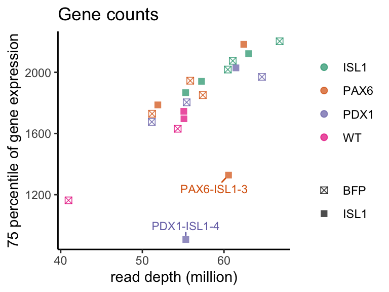

```r
gene_info = gene_info[w2kp,]

meta$read_depth = colSums(cts_dat)/1e6
meta$q75 = apply(cts_dat, 2, quantile, probs = 0.75)
meta$detected_genes = colSums(cts_dat > 0)
meta$top_gene_fraction = apply(cts_dat, 2, function(x) max(x)/sum(x))
meta$top20_fraction = apply(cts_dat, 2, function(x) sum(sort(x, decreasing = TRUE)[1:20])/sum(x))
meta$q75_outlier = meta$read_depth > 50 & meta$q75 < 1500

# add label to the two points with read_depth above 50 and q75 below 1500

g_counts = ggplot(meta, aes(x = read_depth, y = q75, color = cell_line, shape = OE_status)) +
  geom_point(size = 2, alpha = 0.7) +
  geom_text_repel(
    data = subset(meta, read_depth > 50 & q75 < 1500),
    aes(label = clonal.label),     # whichever column holds the sample name
    size = 3,
    show.legend = FALSE,           # don't add a label glyph to the legend
    max.overlaps = Inf,            # don't silently drop labels if crowded
    box.padding = 0.4,
    point.padding = 0.3,
    min.segment.length = 0
  ) +
  ggtitle("Gene counts") +
  xlab("read depth (million)") +
  ylab("75 percentile of gene expression") +
  scale_color_brewer(palette = "Dark2") +
  scale_shape_manual(values = c(7, 15, 16, 17)) +
  guides(
    color = guide_legend(title = NULL, order = 1),
    shape = guide_legend(title = NULL, order = 2)
  )

print(g_counts)
```

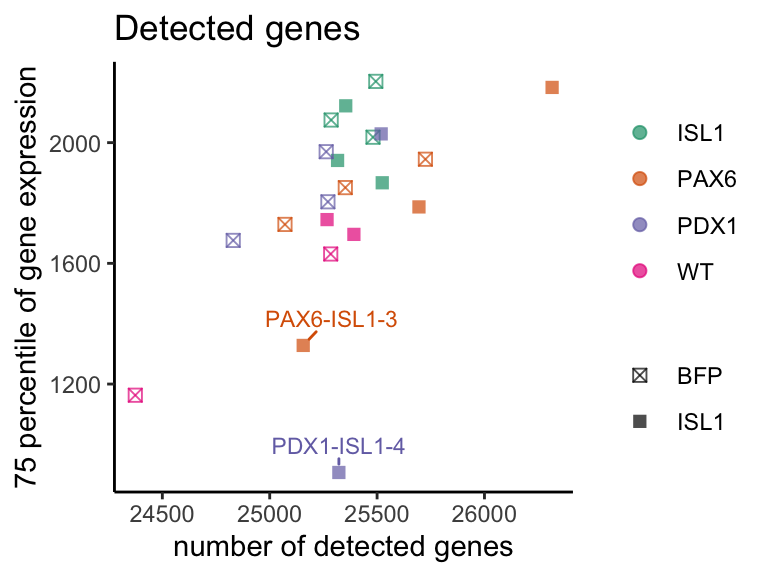

```r
g_detected_genes = ggplot(meta, aes(x = detected_genes, y = q75,
                                    color = cell_line, shape = OE_status)) +
  geom_point(size = 2, alpha = 0.7) +
  geom_text_repel(
    data = subset(meta, q75_outlier),
    aes(label = clonal.label),
    size = 3,
    show.legend = FALSE,
    max.overlaps = Inf,
    box.padding = 0.4,
    point.padding = 0.3,
    min.segment.length = 0
  ) +
  ggtitle("Detected genes") +
  xlab("number of detected genes") +
  ylab("75 percentile of gene expression") +
  scale_color_brewer(palette = "Dark2") +
  scale_shape_manual(values = c(7, 15, 16, 17)) +
  guides(
    color = guide_legend(title = NULL, order = 1),
    shape = guide_legend(title = NULL, order = 2)
  )

print(g_detected_genes)
```

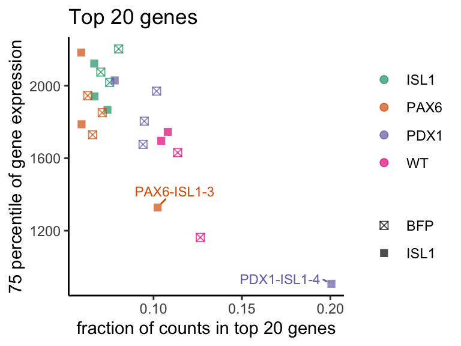

```r
g_top20_fraction = ggplot(meta, aes(x = top20_fraction, y = q75,
                                    color = cell_line, shape = OE_status)) +
  geom_point(size = 2, alpha = 0.7) +
  geom_text_repel(
    data = subset(meta, q75_outlier),
    aes(label = clonal.label),
    size = 3,
    show.legend = FALSE,
    max.overlaps = Inf,
    box.padding = 0.4,
    point.padding = 0.3,
    min.segment.length = 0
  ) +
  ggtitle("Top 20 genes") +
  xlab("fraction of counts in top 20 genes") +
  ylab("75 percentile of gene expression") +
  scale_color_brewer(palette = "Dark2") +
  scale_shape_manual(values = c(7, 15, 16, 17)) +
  guides(
    color = guide_legend(title = NULL, order = 1),
    shape = guide_legend(title = NULL, order = 2)
  )

print(g_top20_fraction)
```

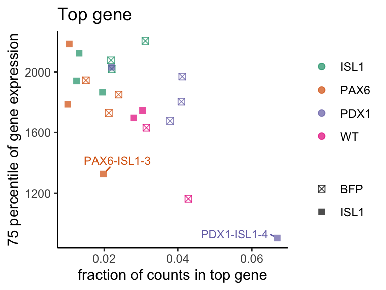

```r
g_top_gene_fraction = ggplot(meta, aes(x = top_gene_fraction, y = q75,
                                       color = cell_line, shape = OE_status)) +
  geom_point(size = 2, alpha = 0.7) +
  geom_text_repel(
    data = subset(meta, q75_outlier),
    aes(label = clonal.label),
    size = 3,
    show.legend = FALSE,
    max.overlaps = Inf,
    box.padding = 0.4,
    point.padding = 0.3,
    min.segment.length = 0
  ) +
  ggtitle("Top gene") +
  xlab("fraction of counts in top gene") +
  ylab("75 percentile of gene expression") +
  scale_color_brewer(palette = "Dark2") +
  scale_shape_manual(values = c(7, 15, 16, 17)) +
  guides(
    color = guide_legend(title = NULL, order = 1),
    shape = guide_legend(title = NULL, order = 2)
  )

print(g_top_gene_fraction)
```

```r
g_qc_2x2 = ggarrange(g_counts, g_detected_genes, g_top20_fraction, g_top_gene_fraction,
                     ncol = 2, nrow = 2)
qc_pdf = file.path(qc_path, "MSK_ISL1_OE_q75_outlier_qc.pdf")
ggsave(qc_pdf, g_qc_2x2, width = 9, height = 7, units = "in")
#print(g_qc_2x2)


qc_df = meta[, c("clonal.label", "label", "read_depth", "q75", "detected_genes",
                 "top_gene_fraction", "top20_fraction", "q75_outlier")]
head(qc_df[order(qc_df$q75),])
```

```
##    clonal.label     label read_depth  q75 detected_genes top_gene_fraction
## 17  PDX1-ISL1-4 PDX1-ISL1   55.32417  907          25322        0.06692175
## 19     WT-BFP-3    WT-BFP   40.95893 1163          24374        0.04285701
## 12  PAX6-ISL1-3 PAX6-ISL1   60.55632 1328          25156        0.01976167
## 18     WT-BFP-1    WT-BFP   54.33452 1631          25284        0.03144211
## 15   PDX1-BFP-3  PDX1-BFP   51.16069 1676          24830        0.03788135
## 21    WT-ISL1-2   WT-ISL1   55.09723 1696          25392        0.02800678
##    top20_fraction q75_outlier
## 17     0.20058877        TRUE
## 19     0.12642958       FALSE
## 12     0.10228199        TRUE
## 18     0.11365626       FALSE
## 15     0.09405608       FALSE
## 21     0.10433174       FALSE
```

```r
outlier_samples = meta$clonal.label[meta$q75_outlier]
top2_outlier_genes = do.call(rbind, lapply(outlier_samples, function(cur_sample) {
  cur_counts = cts_dat[, cur_sample]
  top2_idx = head(order(cur_counts, decreasing = TRUE), 2)
  data.frame(
    sample = cur_sample,
    gene_id = rownames(cts_dat)[top2_idx],
    hgnc_symbol = gene_anno$hgnc_symbol[match(rownames(cts_dat)[top2_idx],
                                               gene_anno$ensembl_gene_id)],
    count = cur_counts[top2_idx],
    fraction = cur_counts[top2_idx]/sum(cur_counts),
    row.names = NULL
  )
}))

top2_outlier_genes
```

```
##        sample         gene_id hgnc_symbol   count   fraction
## 1 PAX6-ISL1-3 ENSG00000100604        CHGA 1196694 0.01976167
## 2 PAX6-ISL1-3 ENSG00000157017        GHRL  809989 0.01337580
## 3 PDX1-ISL1-4 ENSG00000115263         GCG 3702390 0.06692175
## 4 PDX1-ISL1-4 ENSG00000254647         INS 1753888 0.03170202
```

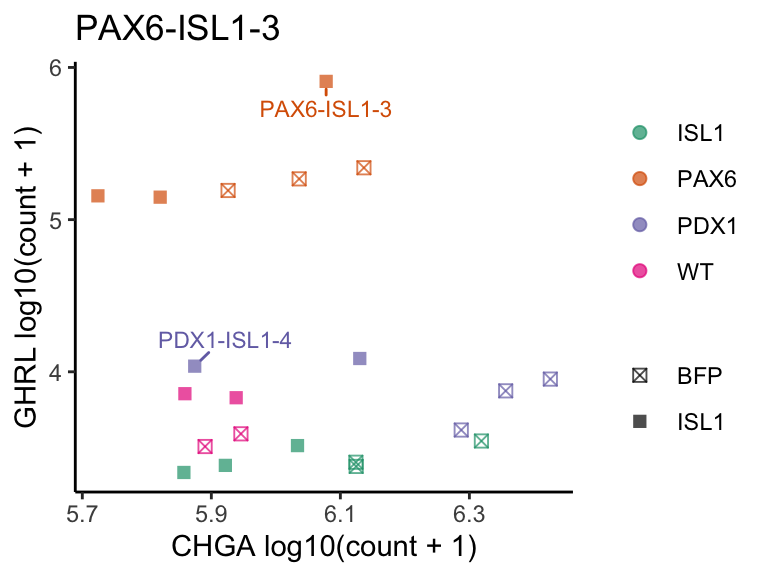

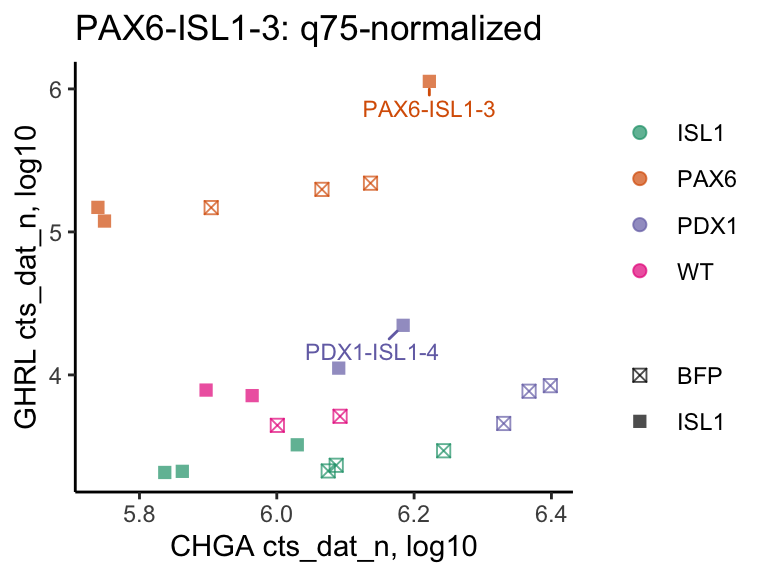

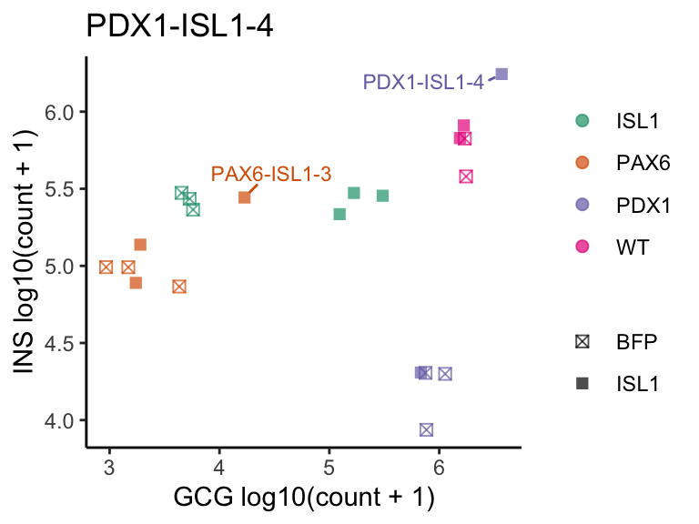

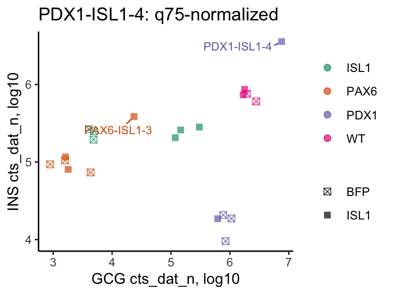

```r
cts_dat_n_qc = log10(t(cts_dat) + 1)
stopifnot(all(rownames(cts_dat_n_qc) == meta$clonal.label))

plot_top2_gene_pair = function(cur_sample) {
  cur_top2 = top2_outlier_genes[top2_outlier_genes$sample == cur_sample,]
  stopifnot(nrow(cur_top2) == 2)

  cur_df = data.frame(
    gene1_expr = cts_dat_n_qc[, cur_top2$gene_id[1]],
    gene2_expr = cts_dat_n_qc[, cur_top2$gene_id[2]],
    meta
  )

  ggplot(cur_df, aes(x = gene1_expr, y = gene2_expr,
                     color = cell_line, shape = OE_status)) +
    geom_point(size = 2, alpha = 0.7) +
    geom_text_repel(
      data = subset(cur_df, clonal.label %in% outlier_samples),
      aes(label = clonal.label),
      size = 3,
      show.legend = FALSE,
      max.overlaps = Inf,
      box.padding = 0.4,
      point.padding = 0.3,
      min.segment.length = 0
    ) +
    ggtitle(cur_sample) +
    xlab(paste0(cur_top2$hgnc_symbol[1], " log10(count + 1)")) +
    ylab(paste0(cur_top2$hgnc_symbol[2], " log10(count + 1)")) +
    scale_color_brewer(palette = "Dark2") +
    scale_shape_manual(values = c(7, 15, 16, 17)) +
    guides(
      color = guide_legend(title = NULL, order = 1),
      shape = guide_legend(title = NULL, order = 2)
    )
}

g_top2_gene_pairs = lapply(outlier_samples, plot_top2_gene_pair)

cts_dat_n_qc_q75 = t(cts_dat)
cts_dat_n_qc_q75 = log10(median(meta$q75)*cts_dat_n_qc_q75/meta$q75 + 1)

plot_top2_gene_pair_q75_norm = function(cur_sample) {
  cur_top2 = top2_outlier_genes[top2_outlier_genes$sample == cur_sample,]
  stopifnot(nrow(cur_top2) == 2)

  cur_df = data.frame(
    gene1_expr = cts_dat_n_qc_q75[, cur_top2$gene_id[1]],
    gene2_expr = cts_dat_n_qc_q75[, cur_top2$gene_id[2]],
    meta
  )

  ggplot(cur_df, aes(x = gene1_expr, y = gene2_expr,
                     color = cell_line, shape = OE_status)) +
    geom_point(size = 2, alpha = 0.7) +
    geom_text_repel(
      data = subset(cur_df, clonal.label %in% outlier_samples),
      aes(label = clonal.label),
      size = 3,
      show.legend = FALSE,
      max.overlaps = Inf,
      box.padding = 0.4,
      point.padding = 0.3,
      min.segment.length = 0
    ) +
    ggtitle(paste0(cur_sample, ": q75-normalized")) +
    xlab(paste0(cur_top2$hgnc_symbol[1], " cts_dat_n, log10")) +
    ylab(paste0(cur_top2$hgnc_symbol[2], " cts_dat_n, log10")) +
    scale_color_brewer(palette = "Dark2") +
    scale_shape_manual(values = c(7, 15, 16, 17)) +
    guides(
      color = guide_legend(title = NULL, order = 1),
      shape = guide_legend(title = NULL, order = 2)
    )
}

g_top2_gene_pairs_q75_norm = lapply(outlier_samples, plot_top2_gene_pair_q75_norm)

for (i in seq_along(outlier_samples)){
  print(g_top2_gene_pairs[[i]])
  print(g_top2_gene_pairs_q75_norm[[i]])
}
```

```r
g_top2_gene_pairs_combined = ggarrange(plotlist = c(g_top2_gene_pairs,
                                                    g_top2_gene_pairs_q75_norm),
                                       ncol = 2, nrow = 2)
top2_gene_pair_combined_pdf = file.path(qc_path,
                                        "MSK_ISL1_OE_q75_outlier_top2_gene_pairs_combined.pdf")
ggsave(top2_gene_pair_combined_pdf, g_top2_gene_pairs_combined,
       width = 7, height = 6.6, units = "in")
# print(g_top2_gene_pairs_combined)
```

## Analyze samples of different model systems or conditions

Explore the PC plots first, to decide which level to run DESeq2 on.

Then run the DE analysis.

Since there is only one day value for each model system, do not include day value in each scatter plot.

```r
meta$model_condition = meta$model_system
table(meta$model_condition)
```

```
##
## Pancreatic_Islet
##               21
```

```
## [1] "Pancreatic_Islet"
```

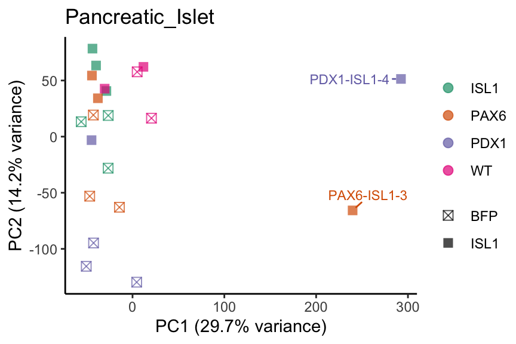

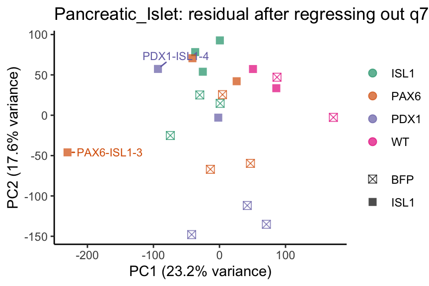

```r
unique_model_condition_ss = unique(meta$model_condition)
unique_model_condition_ss = sort(unique_model_condition_ss)

scatterplots_to_save = list(g_counts)

for(cur_mc in unique_model_condition_ss){

  print(cur_mc)
  sample2kp = which(meta$model_condition == cur_mc)
  cts_dat_m = cts_dat[,sample2kp]
  meta_m    = meta[sample2kp,]

  stopifnot(all(meta_m$clonal.label == colnames(cts_dat_m)))
  q75 = apply(cts_dat_m, 1, quantile, probs=0.75)

  cts_dat_n = t(cts_dat_m[q75 > 0,])
  cts_dat_n = log(median(meta_m$q75)*cts_dat_n/meta_m$q75 + 1)
  dim(cts_dat_n)

  sample_pca = prcomp(cts_dat_n, center = TRUE, scale. = TRUE)
  names(sample_pca)
  pc_scores = sample_pca$x
  eigen_vals = sample_pca$sdev^2
  eigen_vals[1:5]/sum(eigen_vals)
  pvs = round(eigen_vals[1:5]/sum(eigen_vals)*100,1)
  pvs

  PC_df = data.frame(pc_scores)
  PC_df = cbind(PC_df, meta_m)
  pc1_rightmost_samples = head(PC_df$clonal.label[order(-PC_df$PC1)], 2)

  gPC = ggplot(PC_df, aes(x = PC1, y = PC2, shape=OE_status, color=cell_line)) +
    geom_point(size=2.5, alpha=0.7) + scale_color_brewer(palette = "Dark2") +
    geom_text_repel(
      data = subset(PC_df, PC1 > 100),
      aes(label = clonal.label),     # whichever column holds the sample name
      size = 3,
      show.legend = FALSE,           # don't add a label glyph to the legend
      max.overlaps = Inf,            # don't silently drop labels if crowded
      box.padding = 0.4,
      point.padding = 0.3,
      min.segment.length = 0
    ) +
      scale_shape_manual(values = c(7, 15, 16, 17)) +
    xlab(sprintf("PC1 (%.1f%% variance)", pvs[1])) +
    ylab(sprintf("PC2 (%.1f%% variance)", pvs[2])) +
    ggtitle(cur_mc) +
    guides(
      color = guide_legend(title = NULL, order = 1),
      shape = guide_legend(title = NULL, order = 2)
    ) +
    theme(
      legend.margin = margin(0, 0, 0, 0),
      legend.box.just = "left",
      legend.direction = "vertical"
    )

  print(gPC)
  scatterplots_to_save[[length(scatterplots_to_save) + 1]] = gPC

  # All PC1 loadings, named by gene
  pc1_loadings <- sample_pca$rotation[, "PC1"]
  df_pc1_loadings = data.frame(gene_id = names(pc1_loadings),
                               pc1_loading = pc1_loadings)
  # assign the hgnc_symbol
  df_pc1_loadings$hgnc_symbol = gene_anno$hgnc_symbol[match(df_pc1_loadings$gene_id,
                                                            gene_anno$ensembl_gene_id)]
  any(duplicated(df_pc1_loadings$gene_id))
  sum(is.na(df_pc1_loadings$hgnc_symbol))
  sum(df_pc1_loadings$hgnc_symbol == "", na.rm = TRUE)

  rownames(df_pc1_loadings) = NULL

  df_pc1_loadings_top <- df_pc1_loadings[order(-df_pc1_loadings$pc1_loading), ]
  head(df_pc1_loadings_top, 20)

  df_pc1_loadings_bottom <- df_pc1_loadings[order(df_pc1_loadings$pc1_loading), ]
  head(df_pc1_loadings_bottom, 20)

  # generate a histogram of PC1 loadings
  g_pc1_loadings = ggplot(df_pc1_loadings, aes(x=pc1_loading)) +
    geom_histogram(color="darkblue", fill="lightblue", bins = 200) +
    ggtitle(paste0(cur_mc, " PC1 loadings"))
  g_pc1_loadings

  # for each of the genes in df_pc1_loadings_top and df_pc1_loadings_bottom
  # compute the correlation with PC1 values
  cor_top = cor(cts_dat_n[, df_pc1_loadings_top$gene_id[1:20]], pc_scores[, "PC1"])
  cor_bottom = cor(cts_dat_n[, df_pc1_loadings_bottom$gene_id[1:20]], pc_scores[, "PC1"])

  as.numeric(cor_top)
  as.numeric(cor_bottom)

  # Cell cycle hypothesis — score known cell-cycle genes
  cc_genes <- c("MKI67", "TOP2A", "PCNA", "MCM2", "MCM5", "CCNB1", "CCNA2", "CDK1")
  cc_ids <- gene_anno$ensembl_gene_id[gene_anno$hgnc_symbol %in% cc_genes]
  cc_loadings <- df_pc1_loadings$pc1_loading[df_pc1_loadings$gene_id %in% cc_ids]
  summary(cc_loadings)   # are they systematically positive or negative?

  lib_size <- colSums(cts_dat_m)
  cor(sample_pca$x[, "PC1"], lib_size)

  oxphos_genes <- c("SDHA","SDHB","SDHC","SDHD",        # Complex II
                    "COX4I1","COX5A","COX5B","COX6A1",  # Complex IV
                    "NDUFA1","NDUFB1","NDUFS1",         # Complex I
                    "ATP5F1A","ATP5F1B","ATP5F1C",      # Complex V
                    "UQCRC1","UQCRC2")                   # Complex III
  oxphos_ids <- gene_anno$ensembl_gene_id[gene_anno$hgnc_symbol %in% oxphos_genes]
  oxphos_loadings <- df_pc1_loadings$pc1_loading[df_pc1_loadings$gene_id %in% oxphos_ids]
  summary(oxphos_loadings)

  # PC plot if regressing out the read depth (in the format of q75)

  q75_m = apply(cts_dat_m[q75 > 0,], 2, quantile, probs = 0.75)
  stopifnot(all(names(q75_m) == rownames(cts_dat_n)))

  cts_dat_n_log = log(t(cts_dat_m[q75 > 0,]) + 1)
  q75_m_log = log(q75_m + 1)

  cts_dat_q75_resid = apply(cts_dat_n_log, 2, function(expr) {
    residuals(lm(expr ~ q75_m_log))
  })
  rownames(cts_dat_q75_resid) = rownames(cts_dat_n_log)
  resid_gene_sd = apply(cts_dat_q75_resid, 2, sd)
  cts_dat_q75_resid = cts_dat_q75_resid[, resid_gene_sd > 0 & !is.na(resid_gene_sd)]
  dim(cts_dat_q75_resid)

  sample_pca_q75_resid = prcomp(cts_dat_q75_resid, center = TRUE, scale. = TRUE)
  pc_scores_q75_resid = sample_pca_q75_resid$x
  eigen_vals_q75_resid = sample_pca_q75_resid$sdev^2
  pvs_q75_resid = round(eigen_vals_q75_resid[1:5]/sum(eigen_vals_q75_resid)*100, 1)

  PC_df_q75_resid = data.frame(pc_scores_q75_resid)
  PC_df_q75_resid = cbind(PC_df_q75_resid, meta_m)

  gPC_q75_resid = ggplot(PC_df_q75_resid,
                         aes(x = PC1, y = PC2, shape = OE_status, color = cell_line)) +
    geom_point(size = 2.5, alpha = 0.7) +
    scale_color_brewer(palette = "Dark2") +
    geom_text_repel(
      data = subset(PC_df_q75_resid, clonal.label %in% pc1_rightmost_samples),
      aes(label = clonal.label),
      size = 3,
      show.legend = FALSE,
      max.overlaps = Inf,
      box.padding = 0.4,
      point.padding = 0.3,
      min.segment.length = 0
    ) +
    scale_shape_manual(values = c(7, 15, 16, 17)) +
    xlab(sprintf("PC1 (%.1f%% variance)", pvs_q75_resid[1])) +
    ylab(sprintf("PC2 (%.1f%% variance)", pvs_q75_resid[2])) +
    ggtitle(paste0(cur_mc, ": residual after regressing out q75")) +
    guides(
      color = guide_legend(title = NULL, order = 1),
      shape = guide_legend(title = NULL, order = 2)
    ) +
    theme(
      legend.margin = margin(0, 0, 0, 0),
      legend.box.just = "left",
      legend.direction = "vertical"
    )

  print(gPC_q75_resid)
  scatterplots_to_save[[length(scatterplots_to_save) + 1]] = gPC_q75_resid

}
```

```r
g_scatterplots_2x2 = ggarrange(plotlist = scatterplots_to_save, ncol = 2, nrow = 2)
scatterplot_pdf = file.path(qc_path, "MSK_ISL1_OE_exploratory_scatterplots.pdf")
ggsave(scatterplot_pdf, g_scatterplots_2x2, width = 9, height = 7, units = "in")
```

## PC after adjusting for read depth following the DESeq2 style scaling

One PC plot after adjusting for read depth following the DESeq2 style scaling

Another PC plot after additionally regressing out the log(q75)

```r
meta$model_condition = meta$model_system
table(meta$model_condition)
```

```
##
## Pancreatic_Islet
##               21
```

```
## [1] "Pancreatic_Islet"
```

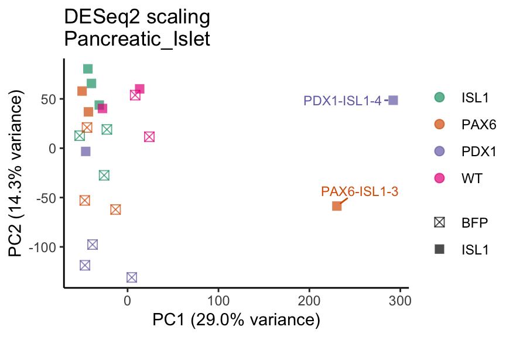

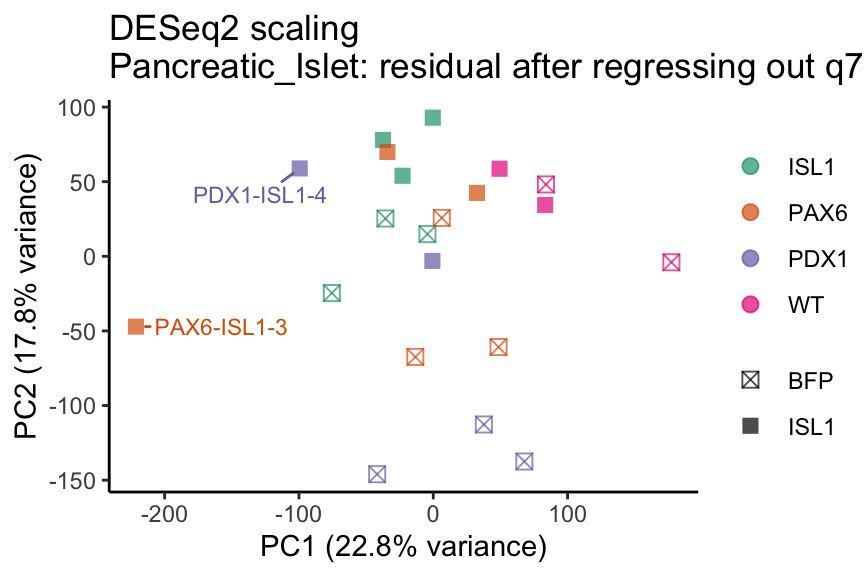

```r
unique_model_condition_ss = unique(meta$model_condition)
unique_model_condition_ss = sort(unique_model_condition_ss)

scatterplots_to_save = list()

for(cur_mc in unique_model_condition_ss){

  print(cur_mc)
  sample2kp = which(meta$model_condition == cur_mc)
  cts_dat_m = cts_dat[,sample2kp]
  meta_m    = meta[sample2kp,]

  stopifnot(all(meta_m$clonal.label == colnames(cts_dat_m)))
  q75 = apply(cts_dat_m, 1, quantile, probs=0.75)

  cts_dat_n = t(cts_dat_m[q75 > 0,])

  # do DESeq style scaling

  trec1 = t(cts_dat_n)
  dim(trec1)

  fun_k_i_r <- function(vec){
    return(prod(vec^(1/length(vec))))
  }

  K_i_R = apply(trec1, 1, fun_k_i_r)
  summary(K_i_R)

  get_s_j <- function(vec1, vec2){
    kept_vec1 = vec1[which(vec2!=0)]
    kept_vec2 = vec2[which(vec2!=0)]
    return(median(kept_vec1/kept_vec2))
  }

  s_j = NULL

  for (j in 1:ncol(trec1)){
    s_j = c(s_j, get_s_j(trec1[, j], K_i_R))
  }

  s_j

  # plot(s_j, colSums(trec1))

  q_ij = matrix(NA, nrow = nrow(trec1), ncol = ncol(trec1))

  for (j in 1:ncol(trec1)){
    q_ij[, j] = trec1[, j]/s_j[j]
  }

  q_mean = apply(q_ij, 1, mean)
  q_median = apply(q_ij, 1, median)

  summary(q_mean)
  summary(q_median)

  q_ij_log = log(q_ij + 1)

  cts_dat_n = t(q_ij_log)


  sample_pca = prcomp(cts_dat_n, center = TRUE, scale. = TRUE)
  names(sample_pca)
  pc_scores = sample_pca$x
  eigen_vals = sample_pca$sdev^2
  eigen_vals[1:5]/sum(eigen_vals)
  pvs = round(eigen_vals[1:5]/sum(eigen_vals)*100,1)
  pvs

  PC_df = data.frame(pc_scores)
  PC_df = cbind(PC_df, meta_m)
  pc1_rightmost_samples = head(PC_df$clonal.label[order(-PC_df$PC1)], 2)

  gPC = ggplot(PC_df, aes(x = PC1, y = PC2, shape=OE_status, color=cell_line)) +
    geom_point(size=2.5, alpha=0.7) + scale_color_brewer(palette = "Dark2") +
    geom_text_repel(
      data = subset(PC_df, PC1 > 100),
      aes(label = clonal.label),     # whichever column holds the sample name
      size = 3,
      show.legend = FALSE,           # don't add a label glyph to the legend
      max.overlaps = Inf,            # don't silently drop labels if crowded
      box.padding = 0.4,
      point.padding = 0.3,
      min.segment.length = 0
    ) +
      scale_shape_manual(values = c(7, 15, 16, 17)) +
    xlab(sprintf("PC1 (%.1f%% variance)", pvs[1])) +
    ylab(sprintf("PC2 (%.1f%% variance)", pvs[2])) +
    ggtitle(paste0("DESeq2 scaling\n", cur_mc)) +
    guides(
      color = guide_legend(title = NULL, order = 1),
      shape = guide_legend(title = NULL, order = 2)
    ) +
    theme(
      legend.margin = margin(0, 0, 0, 0),
      legend.box.just = "left",
      legend.direction = "vertical"
    )

  print(gPC)
  scatterplots_to_save[[length(scatterplots_to_save) + 1]] = gPC

  # PC plot if regressing out the read depth (in the format of q75)

  q75_m = apply(cts_dat_m[q75 > 0,], 2, quantile, probs = 0.75)
  stopifnot(all(names(q75_m) == rownames(cts_dat_n)))

  q75_m_log = log(q75_m + 1)

  cts_dat_q75_resid = apply(cts_dat_n, 2, function(expr) {
    residuals(lm(expr ~ q75_m_log))
  })
  rownames(cts_dat_q75_resid) = rownames(cts_dat_n)
  resid_gene_sd = apply(cts_dat_q75_resid, 2, sd)
  cts_dat_q75_resid = cts_dat_q75_resid[, resid_gene_sd > 0 & !is.na(resid_gene_sd)]
  dim(cts_dat_q75_resid)

  sample_pca_q75_resid = prcomp(cts_dat_q75_resid, center = TRUE, scale. = TRUE)
  pc_scores_q75_resid = sample_pca_q75_resid$x
  eigen_vals_q75_resid = sample_pca_q75_resid$sdev^2
  pvs_q75_resid = round(eigen_vals_q75_resid[1:5]/sum(eigen_vals_q75_resid)*100, 1)

  PC_df_q75_resid = data.frame(pc_scores_q75_resid)
  PC_df_q75_resid = cbind(PC_df_q75_resid, meta_m)

  gPC_q75_resid = ggplot(PC_df_q75_resid,
                         aes(x = PC1, y = PC2, shape = OE_status, color = cell_line)) +
    geom_point(size = 2.5, alpha = 0.7) +
    scale_color_brewer(palette = "Dark2") +
    geom_text_repel(
      data = subset(PC_df_q75_resid, clonal.label %in% pc1_rightmost_samples),
      aes(label = clonal.label),
      size = 3,
      show.legend = FALSE,
      max.overlaps = Inf,
      box.padding = 0.4,
      point.padding = 0.3,
      min.segment.length = 0
    ) +
    scale_shape_manual(values = c(7, 15, 16, 17)) +
    xlab(sprintf("PC1 (%.1f%% variance)", pvs_q75_resid[1])) +
    ylab(sprintf("PC2 (%.1f%% variance)", pvs_q75_resid[2])) +
    ggtitle(paste0("DESeq2 scaling\n", cur_mc, ": residual after regressing out q75")) +
    guides(
      color = guide_legend(title = NULL, order = 1),
      shape = guide_legend(title = NULL, order = 2)
    ) +
    theme(
      legend.margin = margin(0, 0, 0, 0),
      legend.box.just = "left",
      legend.direction = "vertical"
    )

  print(gPC_q75_resid)
  scatterplots_to_save[[length(scatterplots_to_save) + 1]] = gPC_q75_resid

}
```

```r
g_scatterplots_1x2 = ggarrange(plotlist = scatterplots_to_save, ncol = 2, nrow = 1)
scatterplot_pdf = file.path(qc_path, "MSK_ISL1_OE_exploratory_PC_plots_DESeq2_scaling.pdf")
ggsave(scatterplot_pdf, g_scatterplots_1x2, width = 9, height = 3.8, units = "in")
```

Use each combination of (model system, condition) as DE group.

Run analysis for each DE group separately.

For the output files, create two versions, one with direct information, one with padj set to NA for the genes when the number of 0 per test is >=4.

In more details, for both versions of the outputs, make it one file per knockout gene per DE group (DE group can be model system, model system + condition, model system + run_id, model system + day, etc.).

The first version of the output files contains

```
gene id, gene symbol
```

and for each knockout strategy:

```
baseMean, log2FoldChange, lfcSE, stat, pvalue, padj
```

The second version of the output files contains

```
gene id, gene symbol, chr, strand, position
```

and for each knockout strategy:

```
log2FoldChange, pvalue, padj (set to be NA if the number of 0 per test >= 4),
```

In addition, save out a separate file of the sample size for each comparison. This needs to be by DE group.

In this setting, all samples were sequenced in the same batch. Do not consider run.id as a covariate or grouping factor.

### Prepare output directories for DE results

```r
release_name = "2026_01_MSK_bulkRNAseq_ISL1_OE"

output_dir = file.path("results", release_name)
raw_output_dir = file.path(output_dir, "raw")
processed_output_dir = file.path(output_dir, "processed")

if (!file.exists(raw_output_dir)){
  dir.create(raw_output_dir, recursive = TRUE)
}

if (!file.exists(processed_output_dir)){
  dir.create(processed_output_dir, recursive = TRUE)
}
```

### DE analysis for all genes

```r
unique_model_ss = unique(meta$model_system)
unique_model_ss = sort(unique_model_ss)
unique_model_ss
```

```
## [1] "Pancreatic_Islet"
```

```r
# there is only one model system in this dataset
model1 = unique_model_ss

  print(model1)
```

```
## [1] "Pancreatic_Islet"
```

```r
  sample2kp = which(meta$model_system == model1)
  cts_dat_m = cts_dat[,sample2kp]
  meta_m    = meta[sample2kp,]

  stopifnot(all(meta_m$clonal.label == colnames(cts_dat_m)))
  print(table(meta_m$clonal.label == colnames(cts_dat_m), useNA="ifany"))
```

```
##
## TRUE
##   21
```

```r
  ## Generate sample information matrix
  # cols2kp = c("model_system", "condition", "ko_strategy", "ko_gene", "run_id",
  #             "run_id_short", "q75", "timepoint")
  cols2kp = c("model_system", "cell_line", "OE_status", "q75", "timepoint")
  sample_info = meta_m[,cols2kp]
  colnames(sample_info)[which(colnames(sample_info)=="timepoint")] = "day"

  dim(sample_info)
```

```
## [1] 21  5
```

```r
  sample_info[1:2,]
```

```
##       model_system cell_line OE_status  q75 day
## 1 Pancreatic_Islet      ISL1       BFP 2018  18
## 2 Pancreatic_Islet      ISL1       BFP 2075  18
```

```r
  print(table(sample_info$cell_line, sample_info$OE_status))
```

```
##
##        BFP ISL1
##   ISL1   3    3
##   PAX6   3    3
##   PDX1   3    2
##   WT     2    2
```

```r
  sample_info$ko_group = paste(sample_info$cell_line,
                               sample_info$OE_status, sep="_")
  print(table(sample_info$ko_group))
```

```
##
##  ISL1_BFP ISL1_ISL1  PAX6_BFP PAX6_ISL1  PDX1_BFP PDX1_ISL1    WT_BFP   WT_ISL1
##         3         3         3         3         3         2         2         2
```

```r
  # use the combination of (model system, condition) as DE group

  sample_info$model_day = paste0(sample_info$model_system,
                                 "_day_",
                                 as.character(sample_info$day))

  sample_info$de_grp = sample_info$model_day

  sorted_de_grps = sort(unique(sample_info$de_grp))
  sorted_de_grps
```

```
## [1] "Pancreatic_Islet_day_18"
```

```r
  # there is only one de_group in this dataset
  d_group = sorted_de_grps

    print(d_group)
```

```
## [1] "Pancreatic_Islet_day_18"
```

```r
    dg_index = which(sample_info$de_grp==d_group)
    cts_dat_m_dg = cts_dat_m[, dg_index]
    sample_info_dg = sample_info[dg_index, ]

    stopifnot(all(sample_info_dg$de_grp==d_group))

    print("-----------------------------------")
```

```
## [1] "-----------------------------------"
```

```r
    print(paste0("Model system: ", model1))
```

```
## [1] "Model system: Pancreatic_Islet"
```

```r
    print(sprintf("DE analysis group %s DESeq2 results:", d_group))
```

```
## [1] "DE analysis group Pancreatic_Islet_day_18 DESeq2 results:"
```

```r
    print("-----------------------------------")
```

```
## [1] "-----------------------------------"
```

```r
    # do two steps of filtering
    # first, filter based on q75 of each gene
    # second, filter based on whether each gene is expressed in at least 4 samples

    dg_q75 = apply(cts_dat_m_dg, 1, quantile, probs=0.75)
    cts_dat_m_dg = cts_dat_m_dg[dg_q75 > 0,]

    print(sprintf("After filtering by gene expression q75, the number of genes reduces from %d to %d",
                  length(dg_q75), nrow(cts_dat_m_dg)))
```

```
## [1] "After filtering by gene expression q75, the number of genes reduces from 28137 to 28137"
```

```r
    n_pos = rowSums(cts_dat_m_dg>0)
    cts_dat_m_dg = cts_dat_m_dg[n_pos >= 4,]

    if (length(n_pos)==nrow(cts_dat_m_dg)){
      print("After filtering by nonzero expression in at least 4 samples, the number of genes does not change.")
    }else{
      print(sprintf("After filtering by nonzero expression in at least 4 samples, the number of genes reduces from %d to %d",
                    length(n_pos), nrow(cts_dat_m_dg)))
    }
```

```
## [1] "After filtering by nonzero expression in at least 4 samples, the number of genes does not change."
```

```r
    # update the q75 based on only genes used in the process
    sample_info_dg$q75 = apply(cts_dat_m_dg, 2, quantile, probs = 0.75)
    sample_info_dg$log_q75 = log(sample_info_dg$q75)

    # mean center log_q75
    sample_info_dg$log_q75 = sample_info_dg$log_q75 - mean(sample_info_dg$log_q75)


    # if (length(unique(sample_info_dg$run_id))==1){
      dds = DESeqDataSetFromMatrix(cts_dat_m_dg, colData=sample_info_dg,
                                    ~ ko_group + log_q75)
    # }else{
    #   dds = DESeqDataSetFromMatrix(cts_dat_m_dg, colData=sample_info_dg,
    #                                 ~ ko_group + run_id + log_q75)
    # }

    start.time <- Sys.time()
    dds = DESeq(dds)
    end.time <- Sys.time()

    time.taken <- end.time - start.time
    print(time.taken)
```

```
## Time difference of 16.6999 secs
```

```r
    ## association with read-depth
    res_rd = results(dds, name = "log_q75")
    res_rd = as.data.frame(res_rd)
    dim(res_rd)
```

```
## [1] 28137     6
```

```r
    res_rd[1:2,]
```

```
##                   baseMean log2FoldChange     lfcSE      stat       pvalue
## ENSG00000271254 656.246815       2.852611 0.6032144  4.729017 2.256097e-06
## ENSG00000276345   4.584155      -2.366975 2.3056333 -1.026605 3.046065e-01
##                         padj
## ENSG00000271254 1.541656e-05
## ENSG00000276345 4.142920e-01
```

```r
    table(is.na(res_rd$padj))
```

```
##
## FALSE  TRUE
## 23773  4364
```

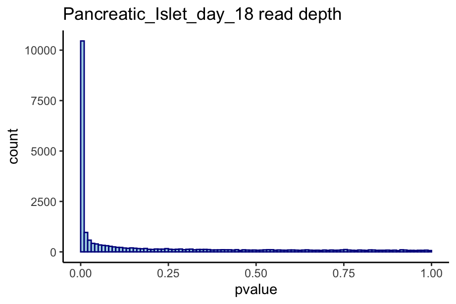

```r
    g0 = ggplot(res_rd %>% subset(!is.na(padj)), aes(x=pvalue)) +
      geom_histogram(color="darkblue", fill="lightblue",
                     breaks = seq(0,1,by=0.01)) +
      ggtitle(paste0(d_group, " read depth"))
    print(g0)
```

```r
    ## Rerun the analysis without read-depth if it is not significant for
    ## most genes, and the number of samples is small
    ## i.e., proportion of non-null in the distribution is smaller than 0.01
    ## (this needs to be restricted to the genes with not NA adjusted pvalue)
    ## or if smaller than 0.1 and the number of samples is not greater than 6

    pi_1_rd = max(0, mean(res_rd$pvalue[!is.na(res_rd$padj)] < 0.05) - 0.05)
    pi_1_rd = max(pi_1_rd, 0, 1 - 2*mean(res_rd$pvalue[!is.na(res_rd$padj)] > 0.5))

    print(sprintf("prop of non-null for rd: %.2e", pi_1_rd))
```

```
## [1] "prop of non-null for rd: 6.41e-01"
```

```r
    if(pi_1_rd < 0.01 || (ncol(cts_dat_m_dg) <= 6 && pi_1_rd < 0.1 )){

      print("rerun DESeq2 without read depth")

      include_rd = 0
      # if (length(unique(sample_info_dg$run_id))==1){
        dds = DESeqDataSetFromMatrix(cts_dat_m_dg, colData=sample_info_dg,
                                      ~ ko_group)
      # }else{
      #   dds = DESeqDataSetFromMatrix(cts_dat_m_dg, colData=sample_info_dg,
      #                                 ~ ko_group + run_id)
      # }
      start.time <- Sys.time()
      dds = DESeq(dds)
      end.time <- Sys.time()

      time.taken <- end.time - start.time
      print(time.taken)

    }else{
      include_rd = 1
    }


    ## ---- Patch dispersion 'seed-revert' artifact (selected genes) -----------
    ## After comparing the DE results with those generated by running limma-voom,
    ## in multiple settings of constrast, there is one gene GCG that have
    ## -log10(pvalue from limma-voom / pvalue from DESeq2) > 3
    ## in DESeq2, GCG had high counts and a large fold change but was not
    ## significant because its final DESeq2 dispersion was very large.
    ## GCG has its gene-wise dispersion reverted to DESeq2's design-blind moments
    ## seed: fitDisp reaches the correct value,
    ## but the 'noIncrease' guard (threshold = |initial_lp|/1e6,
    ## which is huge for high-count genes) discards the improvement, leaving
    ## dispGeneEst == the seed. Such a gene is then flagged as a dispOutlier and
    ## left UNSHRUNK, so an inflated dispersion goes into the Wald test and
    ## mis-tests it. Fix: re-estimate dispersion with niter=2 (which skips the
    ## niter==1 revert guard), then override the FINAL dispersion for this gene
    ## only and re-run the Wald test. Scoped edit -- all other genes unchanged.
    patch_ids <- c("ENSG00000115263") # GCG
    patch <- which(rownames(dds) %in% patch_ids)

    if(length(patch) > 0){
      dds_probe    <- estimateDispersionsGeneEst(dds, niter = 2)   # copy; dds unchanged
      disp_before  <- mcols(dds)$dispGeneEst[patch]
      final_before <- dispersions(dds)[patch]
      disp_after   <- mcols(dds_probe)$dispGeneEst[patch]
      rm(dds_probe)
      ## only patch genes whose un-reverted estimate is materially lower (i.e. the
      ## artifact is present); leave any that are genuinely high-dispersion as-is
      keep <- which(!is.na(disp_after) & !is.na(disp_before) &
                    disp_after < 0.5 * disp_before)
      if(length(keep) > 0){
        patch <- patch[keep]
        print(sprintf("patching dispersion for %d gene(s): %s",
                      length(patch), paste(rownames(dds)[patch], collapse = ", ")))
        print(data.frame(gene               = rownames(dds)[patch],
                         dispGeneEst_before = signif(disp_before[keep], 4),
                         finalDisp_before   = signif(final_before[keep], 4),
                         dispGeneEst_niter2 = signif(disp_after[keep], 4),
                         dispFit            = signif(mcols(dds)$dispFit[patch], 4),
                         dispOutlier        = if ("dispOutlier" %in% names(mcols(dds))) mcols(dds)$dispOutlier[patch] else NA))

        dispersions(dds)[patch] <- disp_after[keep]
        dds <- nbinomWaldTest(dds)               # re-fit SEs with patched dispersions
      }
    }
```

```
## [1] "patching dispersion for 1 gene(s): ENSG00000115263"
##              gene dispGeneEst_before finalDisp_before dispGeneEst_niter2
## 1 ENSG00000115263              2.692            2.692             0.2514
##   dispFit dispOutlier
## 1 0.04113        TRUE
```

```r
    ## -------------------------------------------------------------------------

    ## association with run_id

    # if (length(unique(sample_info_dg$run_id))>1){
    #
    #   if(include_rd){
    #     dds_lrt = DESeq(dds, test="LRT", reduced = ~ ko_group + log_q75)
    #   }else{
    #     dds_lrt = DESeq(dds, test="LRT", reduced = ~ ko_group)
    #   }
    #
    #   res_lrt = results(dds_lrt)
    #
    #   res_run_id = as.data.frame(res_lrt)
    #   dim(res_run_id)
    #   res_run_id[1:2,]
    #
    #   table(is.na(res_run_id$padj))
    #
    #   g0 = ggplot(res_run_id %>% subset(!is.na(padj)), aes(x=pvalue)) +
    #     geom_histogram(color="darkblue", fill="lightblue",
    #                    breaks = seq(0,1,by=0.01)) +
    #     ggtitle(paste0(d_group, " Run ID"))
    #   print(g0)
    #
    # }

    ## DE analysis for two types of comparisons
    ## 1. under each cell line, ISL1 OE vs BFP only
    ## 2. under BFP only, each knockout gene vs WT

    table(sample_info_dg$OE_status)
```

```
##
##  BFP ISL1
##   11   10
```

```r
    table(sample_info_dg$OE_status, sample_info_dg$cell_line)
```

```
##
##        ISL1 PAX6 PDX1 WT
##   BFP     3    3    3  2
##   ISL1    3    3    2  2
```

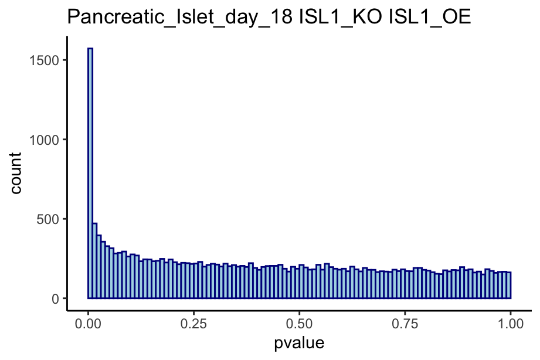

```
## [1] "hgnc_symbol empty string and NA tables:"
##
## FALSE  <NA>
## 20990  7147
##
## FALSE  TRUE
## 20990  7147
```

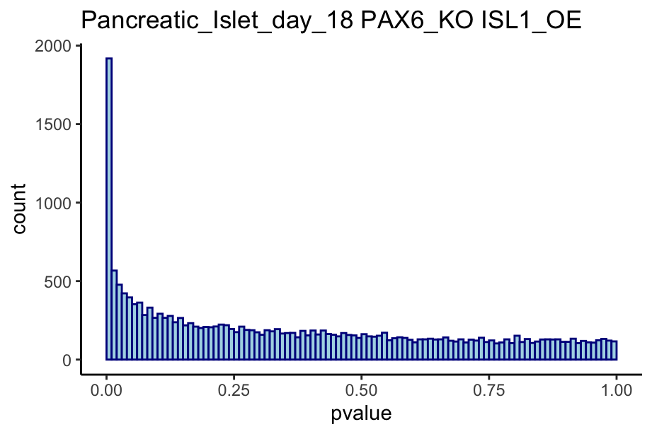

```
## [1] "hgnc_symbol empty string and NA tables:"
##
## FALSE  <NA>
## 20990  7147
##
## FALSE  TRUE
## 20990  7147
```

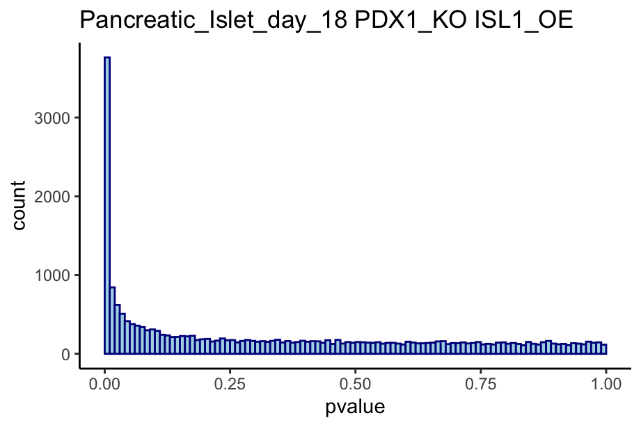

```
## [1] "hgnc_symbol empty string and NA tables:"
##
## FALSE  <NA>
## 20990  7147
##
## FALSE  TRUE
## 20990  7147
```

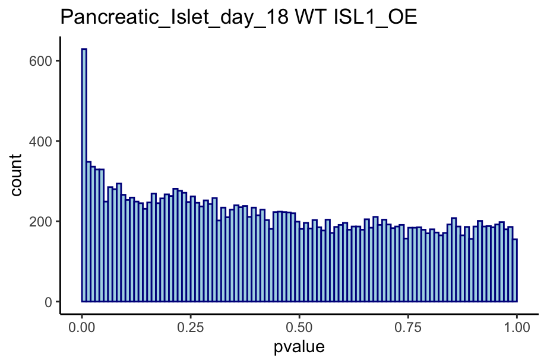

```
## [1] "hgnc_symbol empty string and NA tables:"
##
## FALSE  <NA>
## 20990  7147
##
## FALSE  TRUE
## 20990  7147
```

```r
    target_OE_genes = "ISL1"
    ko_type = "OE"

    cell_lines = unique(sample_info_dg$cell_line)

    # 1. under each cell line, ISL1 OE vs BFP only

    df_size = NULL
    res_cellline = list()

    for(cline in cell_lines){

      res_cellline_df = NULL
      res_cellline_reduced_df = NULL

      if (cline!="WT"){
        cline_str = paste0(cline, "_KO")
      }else{
        cline_str = "WT"
      }

      for(g_oe in target_OE_genes){

        res_g1 = results(dds, contrast = c("ko_group",
                                           paste0(cline, "_", g_oe), paste0(cline, "_BFP")))
        res_g1 = signif(data.frame(res_g1), 3)

        # add a column to record the number of zeros per test
        test_index = which(sample_info_dg$ko_group%in%c(paste0(cline, "_", g_oe), paste0(cline, "_BFP")))

        cts_dat_m_dg_test = cts_dat_m_dg[, test_index]
        n_zero = rowSums(cts_dat_m_dg_test==0)
        res_g1$n_zeros = n_zero

        # record the number of samples involved in the comparison
        test_ko_group_vec = sample_info_dg$ko_group[test_index]

        df_size = rbind(df_size,
                        c(d_group,
                          cline_str,
                          paste0(g_oe, "_", ko_type),
                          sum(test_ko_group_vec!=paste0(cline, "_BFP")),
                          sum(test_ko_group_vec==paste0(cline, "_BFP"))))

        # prepare a processed version of output
        res_g1_reduced = res_g1[, c("log2FoldChange", "pvalue", "padj", "n_zeros")]
        res_g1_reduced$padj[which(res_g1_reduced$n_zeros>=4)] = NA

        if ((sum(test_ko_group_vec!=paste0(cline, "_BFP"))==1)|(sum(test_ko_group_vec==paste0(cline, "_BFP"))==1)){
          res_g1_reduced$padj = NA
        }

        res_g1_reduced = res_g1_reduced[, c("log2FoldChange", "pvalue", "padj")]

        res_cellline[[paste0(cline_str, "_", g_oe, "_", ko_type)]] = res_g1_reduced

        if ((sum(test_ko_group_vec!=paste0(cline, "_BFP"))>1) & (sum(test_ko_group_vec==paste0(cline, "_BFP"))>1)){
          g1 = ggplot(res_g1_reduced %>% subset(!is.na(padj)), aes(x=pvalue)) +
            geom_histogram(color="darkblue", fill="lightblue",
                           breaks = seq(0,1,by=0.01)) +
            ggtitle(paste0(d_group, " ", cline_str, " ", g_oe, "_", ko_type))
          print(g1)
        }


        tag1 = sprintf("%s_%s_", g_oe, ko_type)
        colnames(res_g1) = paste0(tag1, colnames(res_g1))
        colnames(res_g1_reduced) = paste0(tag1, colnames(res_g1_reduced))

        if(is.null(res_cellline_df)){
          res_cellline_df = res_g1
        }else if(!is.null(res_cellline_df)){
          stopifnot(all(rownames(res_cellline_df) == rownames(res_g1)))
          res_cellline_df = cbind(res_cellline_df, res_g1)
        }

        if(is.null(res_cellline_reduced_df)){
          res_cellline_reduced_df = res_g1_reduced
        }else if(!is.null(res_cellline_reduced_df)){
          stopifnot(all(rownames(res_cellline_reduced_df) == rownames(res_g1_reduced)))
          res_cellline_reduced_df = cbind(res_cellline_reduced_df, res_g1_reduced)
        }

      }


      dim(res_cellline_df)
      res_cellline_df[1:2,]

      dim(res_cellline_reduced_df)
      res_cellline_reduced_df[1:2,]

      res_df = data.frame(gene_ID=rownames(res_cellline_df),
                          res_cellline_df)
      dim(res_df)
      res_df[1:2,]

      res_reduced_gene_anno = gene_anno[match(rownames(res_cellline_reduced_df),
                                              gene_anno$ensembl_gene_id), ]
      stopifnot(all(rownames(res_cellline_reduced_df)==res_reduced_gene_anno$ensembl_gene_id))

      # set gene hgnc_symbol that equal "" to NA
      hgnc_symbol_vec = res_reduced_gene_anno$hgnc_symbol
      hgnc_symbol_vec[which(hgnc_symbol_vec=="")] = NA

      res_reduced_df = data.frame(gene_ID=rownames(res_cellline_reduced_df),
                                  hgnc_symbol=hgnc_symbol_vec,
                                  chr=res_reduced_gene_anno$chr,
                                  strand=res_reduced_gene_anno$strand,
                                  start=res_reduced_gene_anno$start,
                                  end=res_reduced_gene_anno$end,
                                  res_cellline_reduced_df)

      print("hgnc_symbol empty string and NA tables:")
      print(table(res_reduced_df$hgnc_symbol=="", useNA="ifany"))
      print(table(is.na(res_reduced_df$hgnc_symbol)))

      dim(res_reduced_df)
      res_reduced_df[1:2,]

      setting_name = unique(paste0(sample_info_dg$model_day, "_",
#                                   sample_info_dg$condition, "_",
                                   cline_str))

      fwrite(res_df,
             sprintf("%s/%s_%s_%s_DEseq2_raw.tsv",
                     raw_output_dir, release_name, setting_name,
                     paste0(g_oe, "_", ko_type)),
             sep="\t")
      fwrite(res_reduced_df,
             sprintf("%s/%s_%s_%s_DEseq2.tsv",
                     processed_output_dir, release_name, setting_name,
                     paste0(g_oe, "_", ko_type)),
             sep="\t")

    }
```

```r
get_index <- function(x){
  which(x$padj < 0.05 & abs(x$log2FoldChange) > log2(1.5))
}

# The four settings
settings    <- names(res_cellline)
short_names <- sub("_.*$", "", settings)

settings
```

```
## [1] "ISL1_KO_ISL1_OE" "PAX6_KO_ISL1_OE" "PDX1_KO_ISL1_OE" "WT_ISL1_OE"
```

```r
short_names
```

```
## [1] "ISL1" "PAX6" "PDX1" "WT"
```

```r
# DE indices and DE gene names per setting
w_list   <- lapply(settings, function(s) get_index(res_cellline[[s]]))
names(w_list) <- settings
de_genes <- lapply(settings, function(s) rownames(res_cellline[[s]])[w_list[[s]]])
names(de_genes) <- settings

print(paste0("DE group ", d_group, " under OE gene ", g_oe, ":"))
```

```
## [1] "DE group Pancreatic_Islet_day_18 under OE gene ISL1:"
```

```r
# Per-setting DE counts
for (i in 1:length(settings)) {
  s <- settings[i]
  short_s <- short_names[i]
  print(paste0("number of DE genes from cell line with knock out gene ", short_s, ": ",
               as.character(length(w_list[[s]]))))
}
```

```
## [1] "number of DE genes from cell line with knock out gene ISL1: 840"
## [1] "number of DE genes from cell line with knock out gene PAX6: 1014"
## [1] "number of DE genes from cell line with knock out gene PDX1: 3268"
## [1] "number of DE genes from cell line with knock out gene WT: 128"
```

```r
# All pairwise overlaps (6 pairs for 4 settings)
pairs <- combn(settings, 2, simplify = FALSE)
for (p in pairs) {
  ov <- length(intersect(de_genes[[p[1]]], de_genes[[p[2]]]))
  print(paste0("number of common DE genes by cell lines with knock out gene ",
               sub("_.*$", "", p[1]), " and ", sub("_.*$", "", p[2]), ": ", as.character(ov)))
}
```

```
## [1] "number of common DE genes by cell lines with knock out gene ISL1 and PAX6: 326"
## [1] "number of common DE genes by cell lines with knock out gene ISL1 and PDX1: 504"
## [1] "number of common DE genes by cell lines with knock out gene ISL1 and WT: 52"
## [1] "number of common DE genes by cell lines with knock out gene PAX6 and PDX1: 667"
## [1] "number of common DE genes by cell lines with knock out gene PAX6 and WT: 72"
## [1] "number of common DE genes by cell lines with knock out gene PDX1 and WT: 70"
```

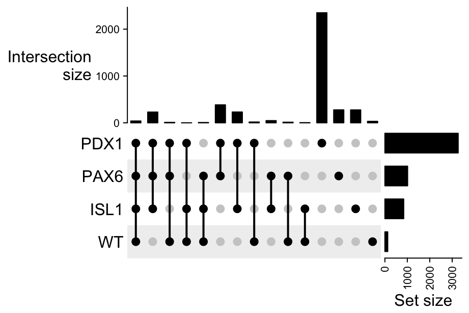

```r
# UpSet plot across all 4 sets (with shortened labels)
if (max(sapply(w_list, length)) > 0) {
  names(de_genes) <- short_names
  m <- make_comb_mat(de_genes)
  g_up <- UpSet(m)
  print(g_up)
  names(de_genes) <- settings   # restore for any downstream use
}
```

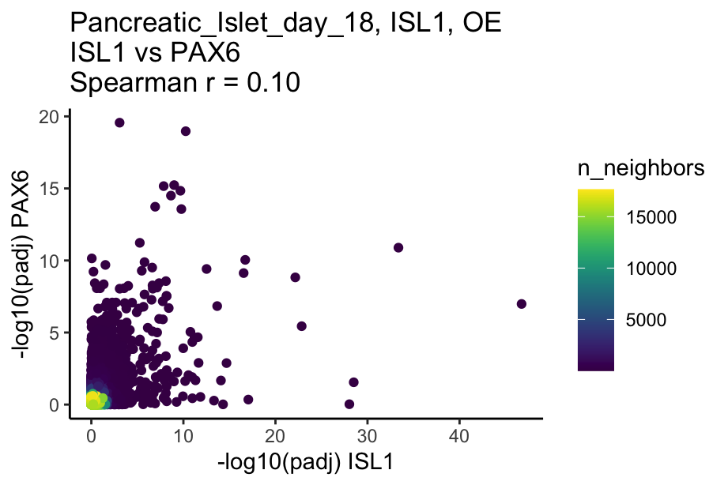

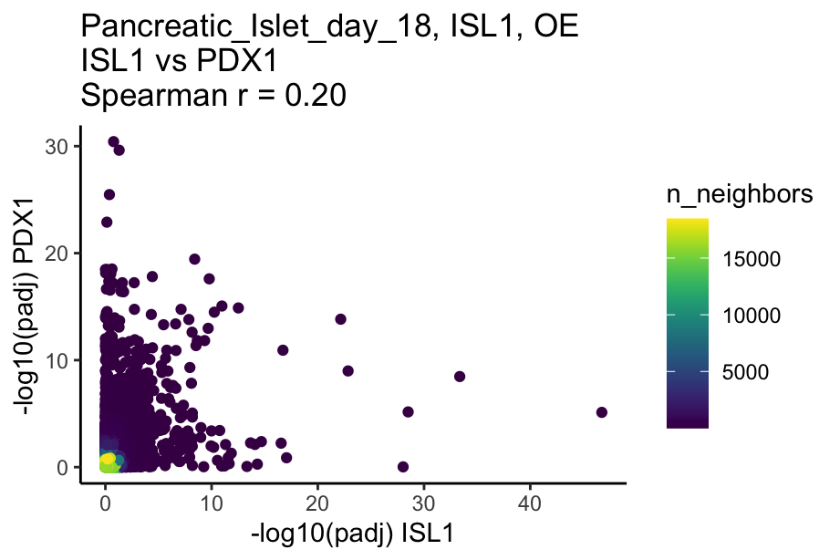

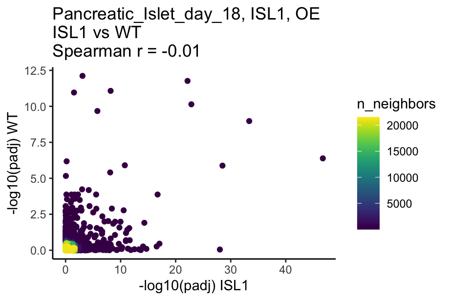

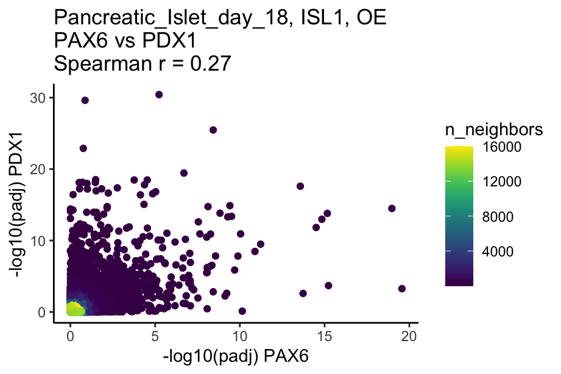

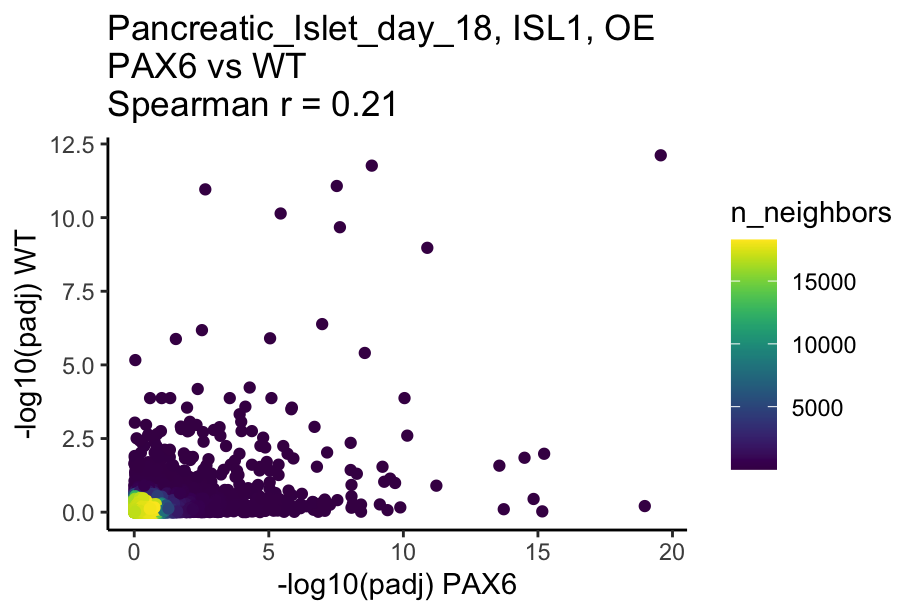

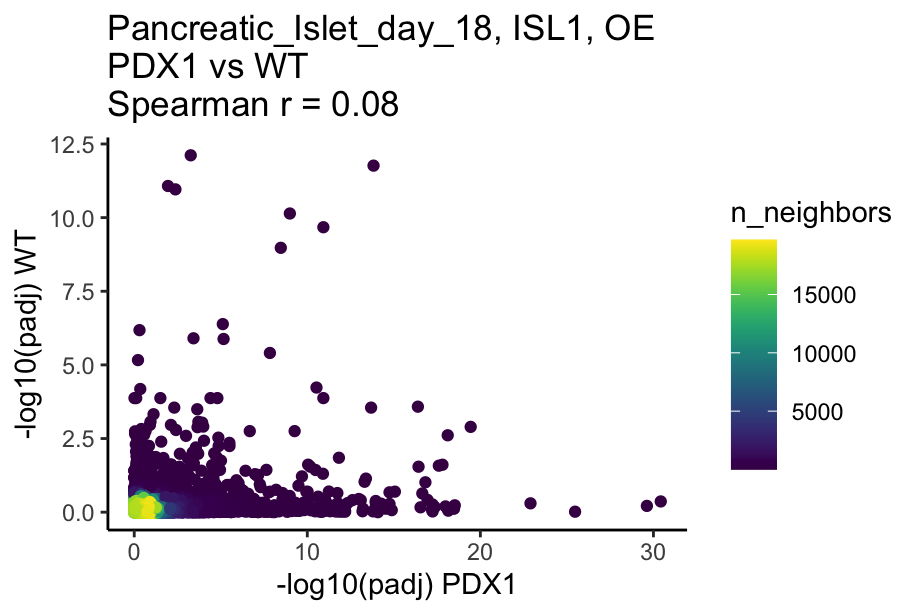

```r
# padj matrix for correlations
df1 <- as.data.frame(sapply(settings, function(s) res_cellline[[s]]$padj))
colnames(df1) <- paste0("padj_", settings)

# Every pairwise scatter (6 plots)
for (p in pairs) {
  x_col <- paste0("padj_", p[1])
  y_col <- paste0("padj_", p[2])
  cr <- cor(df1[[x_col]], df1[[y_col]], method = "spearman", use = "pair")

  df_plot <- data.frame(x = -log10(df1[[x_col]]),
                        y = -log10(df1[[y_col]]))
  df_plot <- df_plot[is.finite(df_plot$x) & is.finite(df_plot$y), ]

  if (nrow(df_plot) < 2) next   # nothing to plot for this pair

  g <- ggplot(df_plot, aes(x = x, y = y)) +
    geom_pointdensity() +
    scale_color_viridis() +
    xlab(paste0("-log10(padj) ", sub("_.*$", "", p[1]))) +
    ylab(paste0("-log10(padj) ", sub("_.*$", "", p[2]))) +
    ggtitle(sprintf("%s, %s, %s\n%s vs %s\nSpearman r = %.2f",
                    d_group, g_oe, ko_type, sub("_.*$", "", p[1]), sub("_.*$", "", p[2]), cr))
  print(g)
}
```

Save the size dataframe out

```r
colnames(df_size) = c("DE_group", "cell_line", "knockout_gene_strategy", "n_ko", "n_WT")
df_size = as.data.frame(df_size)

multi_rows = which(table(df_size$knockout_gene_strategy)>1)
multi_rows
```

```
## ISL1_OE
##       1
```

```r
df_size[which(df_size$knockout_gene_strategy%in%names(multi_rows)),]
```

```
##                  DE_group cell_line knockout_gene_strategy n_ko n_WT
## 1 Pancreatic_Islet_day_18   ISL1_KO                ISL1_OE    3    3
## 2 Pancreatic_Islet_day_18   PAX6_KO                ISL1_OE    3    3
## 3 Pancreatic_Islet_day_18   PDX1_KO                ISL1_OE    2    3
## 4 Pancreatic_Islet_day_18        WT                ISL1_OE    2    2
```

```r
fwrite(df_size,
       sprintf("%s/%s_DE_n_samples.tsv", output_dir, release_name),
       sep="\t")
```

```r
gc()
```

```
##            used  (Mb) gc trigger  (Mb) limit (Mb) max used  (Mb)
## Ncells  8184673 437.2   12711942 678.9         NA 12711942 678.9
## Vcells 32953633 251.5   56710197 432.7      65536 56710197 432.7
```